# The dose makes the poison: Behavioral response of the Southern Redbelly Dace (*Chrosomus erythrogaster*) to chondroitin

Erin Schwarzbach and Mollie Cashner

# 1 Abstract

# 2 Introduction

Various social organisms use chemical alarm cues in order to warn conspecifics of danger. These cues are emitted in times of attack, predation, and perceived threat. The receivers of this signal then respond with behaviors corresponding to increased stress or aggression. This release of chemical alarm substance to conspecific receivers has been studied in organisms ranging from insects through mammals. A well-known case of chemical alarm substance is that of fish. In 1942, Karl von Frisch coined the term “Schreckstoff” to describe the fright response of ostariophysan fish to injured conspecifics. This behavior has been demonstrated numerous times in laboratory settings similar to natural environments. In nature there has been no data showing either a specific habitat or social preference in order for fish to respond. Typically fish that have no specific defense structures respond to the chemical alarm cue. In 1977, Pfeiffer complied data on numerous ostariophysan fish. Pfeiffer showed that my focal species, Chrosomus erythrogaster, demonstrates this fright response. Unlike other organisms such as mice or deer, fish are unable to choose when or if they are going to release their chemical alarm substance (Smith 1992). The fish’s skin must be physically damaged in order for the substance to be released. This is due to the fact that the alarm substance is held in epidermal club cells (Pfeiffer 1977). These club cells are morphologically different from other epidermal cells because they are much more embedded, specifically when compared to mucous cells (Pfeiffer 1977). When the skin is injured, the epidermal club cells are ruptured and are then able to release their contents. The responding conspecifics display numerous behaviors. They may slow their motion or stop moving all together. They may also speed up their movement, move towards the bottom of the tank or natural habitat, spit gas, or form a shoal or school (Pfeiffer 1977). Historically, researchers have used a skin extract to test fish for their fright response. This has worked well in the past, but it is not the best scientific protocol. This is because when a skin extract is used, the exact compounds and concentrations of such compounds are unknown. The molecules compiling the skin extract may change from extract to extract even though the same amount of skin extract is being used. This changed in 2012 when Mathuru et al. used biochemical fractionation to determine the molecules making up the skin extract of the Zebrafish. These researchers uncovered a high molecular weight compound as well as a low molecular weight compound creating different fright responses in fish. The high molecular compound solely elicited slow speeds and freezing, while the low molecular compound created only darting speeds (Mathuru et al. 2012). Upon further inspection, these researchers found the skin extract of the Zebrafish contain multiple chondroitin molecules. Specifically they found that both chondroitin-4-sulfate and chondroitin-6-sulfate both elicit numerous fright responses (Mathuru et al. 2012). The chondroitin molecule is a glycosaminoglycan used for immune homeostasis and in the inflammatory response. While laboratory tests can demonstrate numerous behaviors, these behaviors may not necessarily translate into the field. This project will demonstrate if chondroitin is effective as an alarm substance for Chrosomus erythrogaster, and if the laboratory model is biologically relevant and applicable to the wild. I hypothesize that chondroitin is likely the molecule driving the fright response in Chrosomus erythrogaster. If chondroitin is chemically important, then we expect a fright response elicited from Chrosomus erythrogaster that is no different from that of the skin extract. If this model works in the lab, then I expect that it should also work in the field.

# 3 Methods

## 3.1 Skin Extract Preparation

5 live *Chrosomus erythrogaster* collected from Gause Rd were chilled until torpot. Their spinal cords were severed with a fresh scalpel blade. The skin was peeled from the backs and sides of the fish until 0.45 grams of skin were collected. 20 mL of spring water was placed in a flask and the 0.45 grams of skin extract was added. This mixture was homogenized using a homogenizer. The mixture was filtered over batting into a 500 mL flask. This was a total mixture of 35 mL. 180 mL of spring water was added to the flask. The stimulus was then divided into 5 mL aliquots. These aliquots were frozen until ready to be used for trials.

## 3.4 Location Maps

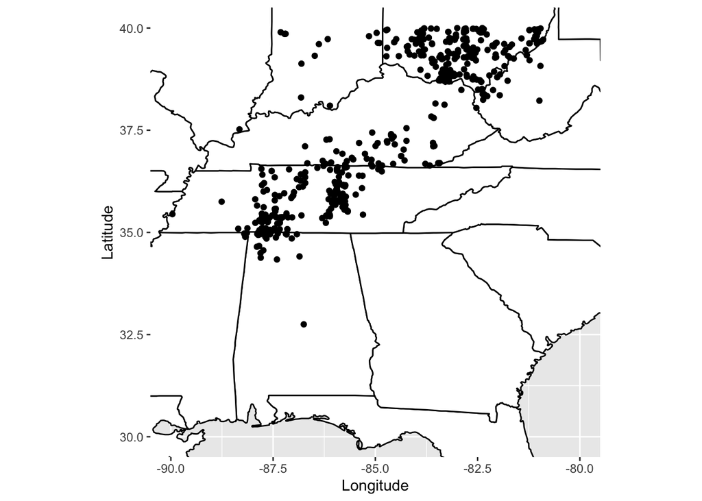

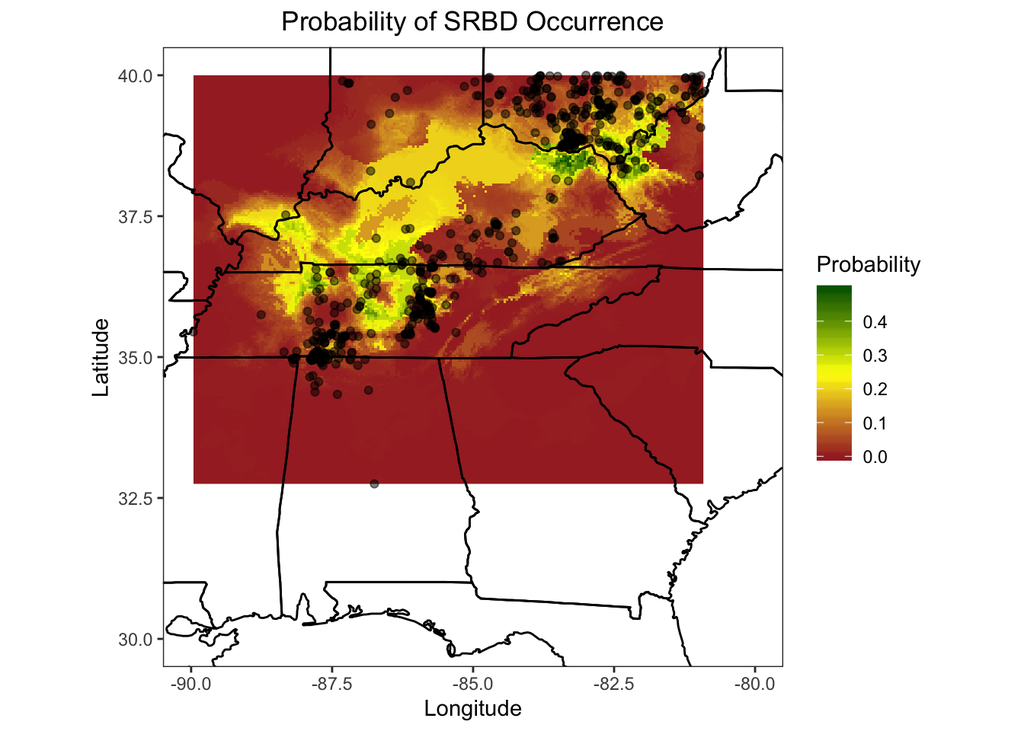

## 3.5 Fish Collection

24 good sized adult *Chrosomus erythrogaster* were collected using a small seine on August 7,2019 from Gause Rd Pleasnt View,TN 37146 (36.4404, -87.0367). These fish were taken back to the lab and quarinted for a week. Within that week, 9 fish had died and another collection event took place at the same location of August 19,2019. During this second collection event, 10 adult *Chrosomus erythrogaster* were collected. Once brought back and quarinted for another week, fish were randomly placed into tanks which were all randomly assigned treatments.

### 3.5.1 Site Description

Field collections were performed at an unnamed tributary of Miller’s Creek. The location is right off of Gause Rd, Pleasant View, TN 37146.

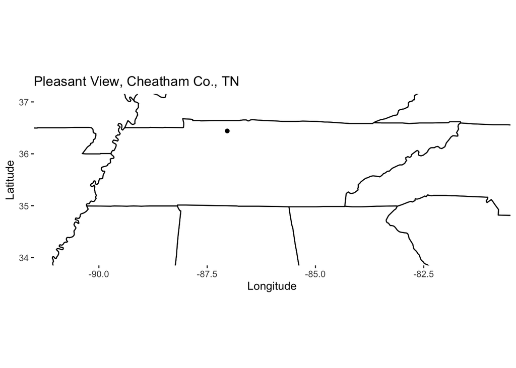

[interactive chart not shown]

## 3.6 Trials

The stimulus were allowed to defrost for two hours before the trials began. Calibration of tanks began at 12:00 pm. Cameras were set up at each tank and a calibration cideo was filmed. The floor was marked where the camera was set up for each tank, so that it could be placed back into the same exact position to film the trial. A one hour break was allowed between calibration and trials for the fish to return to normal behavior. The camera filmed the tank for 3 minutes before a stimulus was added in order to obtain baseline swimming speeds and behaviors. A 5 mL oral syringe was attached to standard aquarium tubing and this was used to obtain the stimulus from its tube. The tip of the aquarium tubing was placed in the corned of the tank on the same side as the airator and the stimulus was dispelled. The tanks were filmed for another three minutes after the stimulus was released.

## 3.7 Video Analysis

Video analysis was performed in VidSync, a 2D and 3D software, which allows speed, depth, and length to be measured.

## 3.8 Data Analysis

All data analysis was perfomed in R.

# 4 Results

## 4.1 Skin

| Time | Speed | Fish | Tank |
| --- | --- | --- | --- |
| Pre | 2.96 | 1 | T1 |
| Pre | 0.99 | 2 | T1 |
| Pre | 0.00 | 3 | T1 |
| Pre | 46.54 | 4 | T2 |
| Pre | 66.08 | 5 | T2 |
| Pre | 123.06 | 6 | T2 |
| Pre | 21.23 | 7 | T4 |
| Pre | 35.04 | 8 | T4 |
| Pre | 33.54 | 9 | T4 |
| Post | 15.37 | 1 | T1 |

[output cut: 8 more lines]

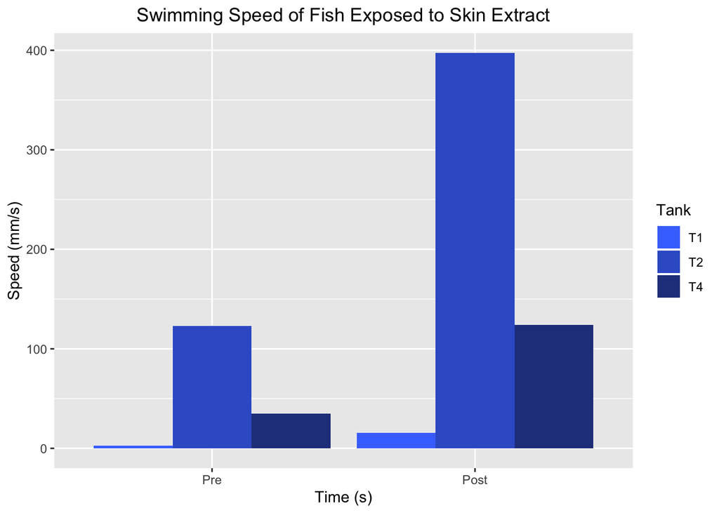

```
##
##  Wilcoxon signed rank test
##
## data:  Speed by Time
## V = 39, p-value = 0.05469
## alternative hypothesis: true location shift is not equal to 0
```

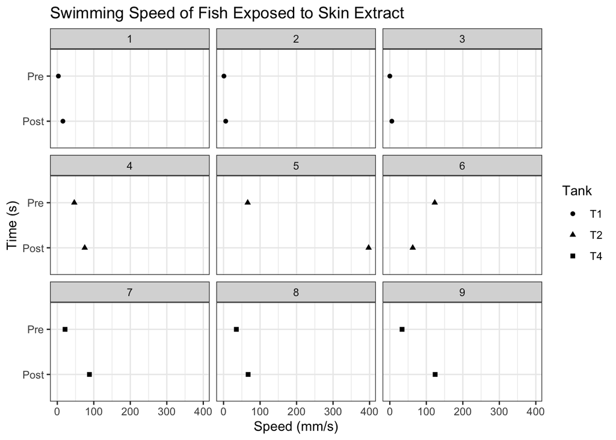

## 4.2 Chondroitin

Speed before and after chondoritin was added to the water was compared using a wilcoxon test.

| Time | Speed | Tank | Fish |
| --- | --- | --- | --- |
| Pre | 13.76 | T3 | 1 |
| Pre | 14.96 | T3 | 2 |
| Pre | 10.55 | T3 | 3 |
| Pre | 25.17 | T5 | 4 |
| Pre | 89.51 | T5 | 5 |
| Pre | 18.81 | T5 | 6 |
| Pre | 32.78 | T6 | 7 |
| Pre | 32.05 | T6 | 8 |
| Pre | 12.22 | T6 | 9 |
| Post | 5.72 | T3 | 1 |

[output cut: 8 more lines]

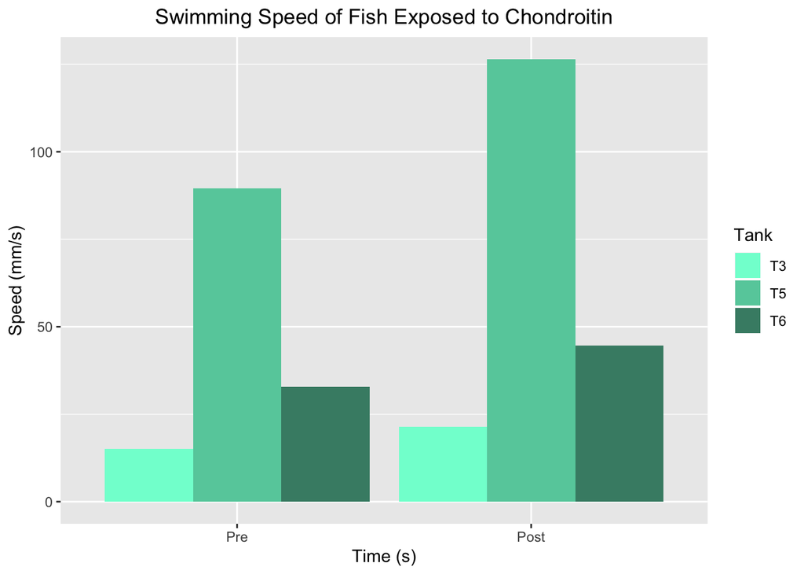

```
##
##  Wilcoxon signed rank test
##
## data:  Speed by Time
## V = 37, p-value = 0.09766
## alternative hypothesis: true location shift is not equal to 0
```

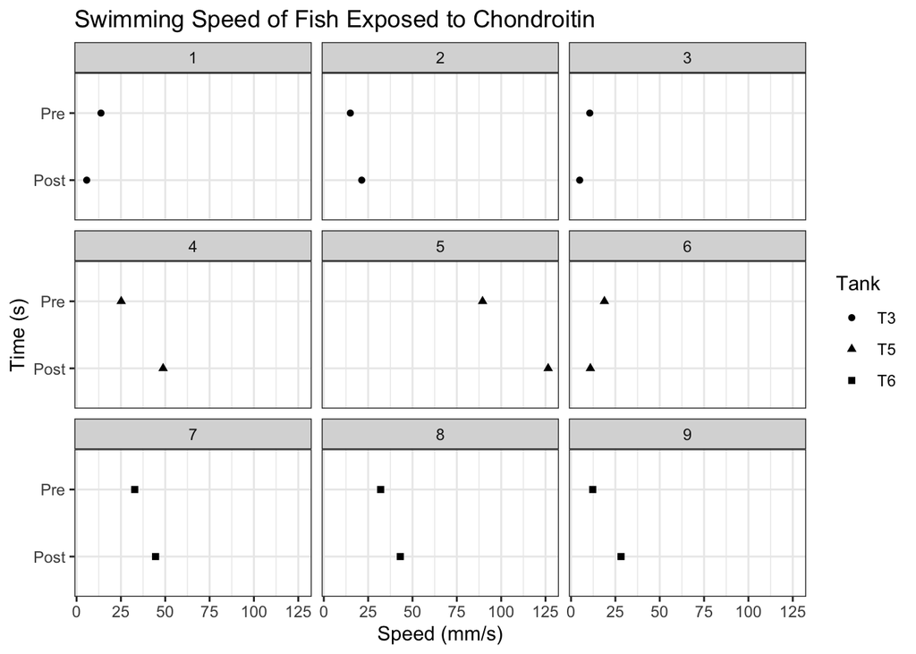

## 4.3 Chondroitin v Skin

Here we are testing the difference in swimming speed post treatment between those tanks that had the skin extract stimulus and those that had the chondroitin stimulus.

| Speed | Tank | Fish | Stimulus | X5 | X6 | X7 | X8 | X9 |
| --- | --- | --- | --- | --- | --- | --- | --- | --- |
| 5.72 | T3 | 1 | Chondroitin | NA | NA | NA | NA | NA |
| 21.37 | T3 | 2 | Chondroitin | NA | NA | NA | NA | NA |
| 4.87 | T3 | 3 | Chondroitin | NA | NA | NA | NA | NA |
| 48.79 | T5 | 4 | Chondroitin | NA | NA | NA | NA | NA |
| 126.49 | T5 | 5 | Chondroitin | NA | NA | NA | NA | NA |
| 10.90 | T5 | 6 | Chondroitin | NA | NA | NA | NA | NA |
| 44.55 | T6 | 7 | Chondroitin | NA | NA | NA | NA | NA |
| 43.13 | T6 | 8 | Chondroitin | NA | NA | NA | NA | NA |
| 28.19 | T6 | 9 | Chondroitin | NA | NA | NA | NA | NA |
| 15.37 | T1 | 1 | Skin | NA | NA | NA | NA | NA |

[output cut: 8 more lines]

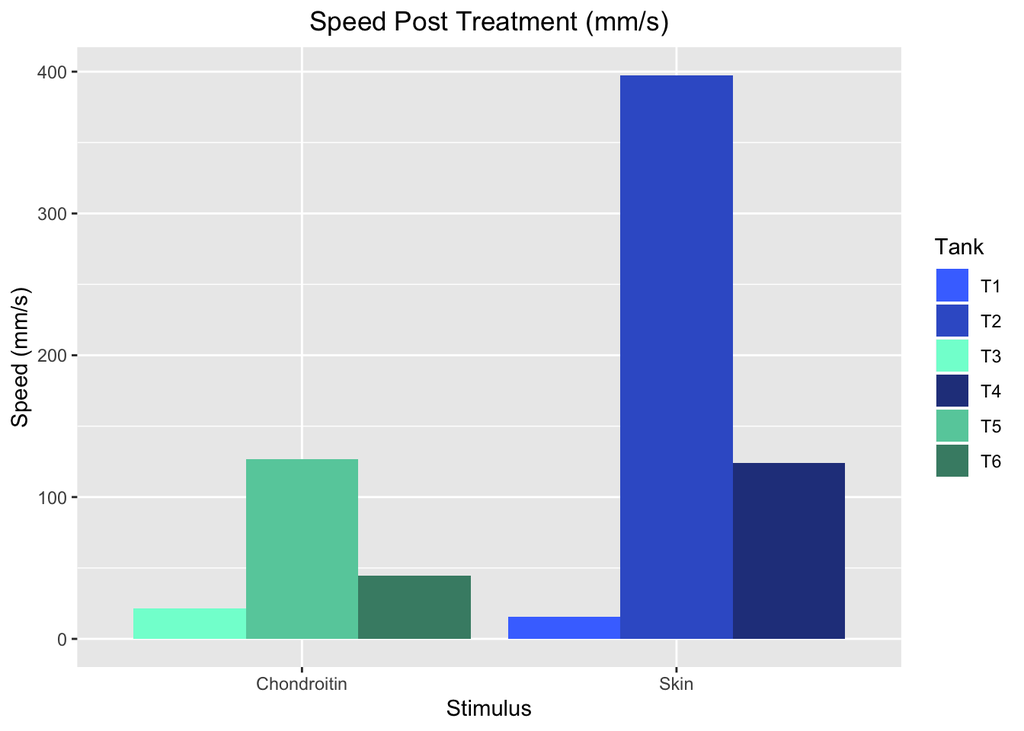

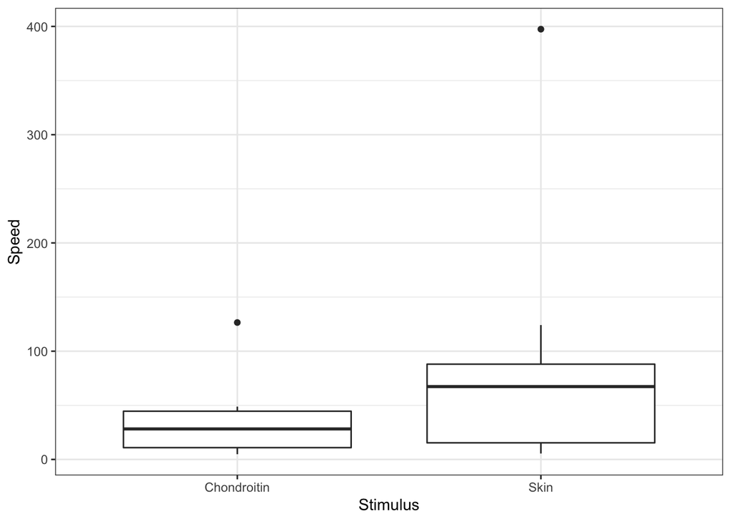

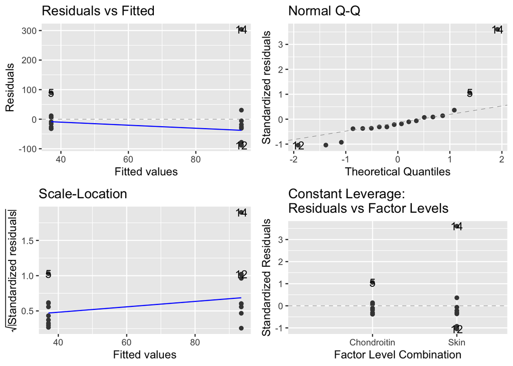

|  | Df | Sum Sq | Mean Sq | F value | Pr(>F) |
| --- | --- | --- | --- | --- | --- |
| Stimulus | 1 | 14316.58 | 14316.576 | 1.788113 | 0.1998575 |
| Residuals | 16 | 128104.44 | 8006.527 | NA | NA |

```
##
## Call:
## lm(formula = Speed ~ Stimulus, data = CvS)
##
## Residuals:
##     Min      1Q  Median      3Q     Max
## -88.007 -31.228 -17.064   7.083 303.943
##
## Coefficients:
##              Estimate Std. Error t value Pr(>|t|)
## (Intercept)     37.11      29.83   1.244    0.231
## StimulusSkin    56.40      42.18   1.337    0.200
##
## Residual standard error: 89.48 on 16 degrees of freedom
## Multiple R-squared:  0.1005, Adjusted R-squared:  0.04431
## F-statistic: 1.788 on 1 and 16 DF,  p-value: 0.1999
```

| Stimulus | meanSpeed |
| --- | --- |
| Chondroitin | 37.11222 |
| Skin | 93.51667 |

From the anova, we get a p-value of 0.1999, which does not show a significant difference between swimming speeds of those tanks exposed to skin extrat and those exposed to chondroitin. When we look at the bar chart, tank 2 has the fastest speeds for skin extract and tank 5 has the fastest speeds for chondoritin, by a large amount. Looking at a complete bar chart to compare chondoroitin speeds to skin extract, we see that while the skin extract mean is faster (93.51 mm/s) comapred to the chondroitin mean (37.11 mm/s), but we also see that each stimulus has one outlier on the higher end.

Besides speed, other behavioral changes such as darting, freezing, and burrowing were measured and compared between stimuli. These behaviors were compared only for the three minutes after the stimulus was added.

## 4.4 Darting

A t-test was used to compared the time fish spent darting once the stimulus was added. There was a significant difference (p=0.0006) in time spent darting between the fish exposed to chondoritin and those exposed to skin extract.

```
##
##  Welch Two Sample t-test
##
## data:  Darting by Stimulus
## t = -5.3638, df = 8.0778, p-value = 0.0006532
## alternative hypothesis: true difference in means is not equal to 0
## 95 percent confidence interval:
##  -32.39524 -12.93809
## sample estimates:
## mean in group chondoritin        mean in group skin
##                 0.5555556                23.2222222
```

| Stimulus | Darting | Tank | Fish |
| --- | --- | --- | --- |
| skin | 11 | T1 | 1 |
| skin | 10 | T1 | 2 |
| skin | 2 | T1 | 3 |
| skin | 25 | T2 | 1 |
| skin | 29 | T2 | 2 |
| skin | 28 | T2 | 3 |
| skin | 36 | T4 | 1 |
| skin | 29 | T4 | 2 |
| skin | 39 | T4 | 3 |
| chondoritin | 0 | T3 | 1 |

[output cut: 8 more lines]

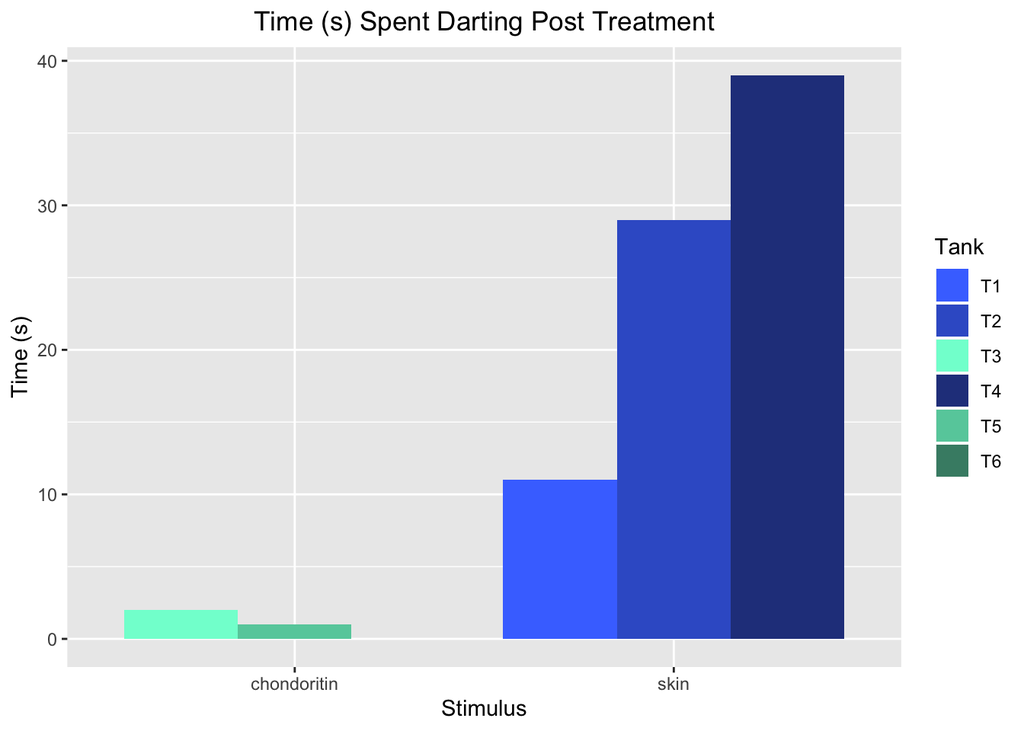

## 4.5 Burrowing

A t-test was used to compared the time fish spent burrowing once the stimulus was added. There was a significant difference (p=0.001) in time spent burrowing between the fish exposed to chondoritin and those exposed to skin extract. In all three tanks where the fish were exposed to skin extract, the fish performed burrowing behaviors, while there was only one tank that was exposed to chondroitin in which the fish displayed burrowing behaviors. This may be due to outside influences.

```
##
##  Welch Two Sample t-test
##
## data:  Burrowing by Stimulus
## t = -4.572, df = 8.3498, p-value = 0.00163
## alternative hypothesis: true difference in means is not equal to 0
## 95 percent confidence interval:
##  -20.843376  -6.934402
## sample estimates:
## mean in group chondoritin        mean in group skin
##                 0.5555556                14.4444444
```

| Stimulus | Burrowing | Tank | Fish |
| --- | --- | --- | --- |
| skin | 5 | T1 | 1 |
| skin | 2 | T1 | 2 |
| skin | 2 | T1 | 3 |
| skin | 20 | T2 | 1 |
| skin | 17 | T2 | 2 |
| skin | 21 | T2 | 3 |
| skin | 26 | T4 | 1 |
| skin | 20 | T4 | 2 |
| skin | 17 | T4 | 3 |
| chondoritin | 0 | T3 | 1 |

[output cut: 8 more lines]

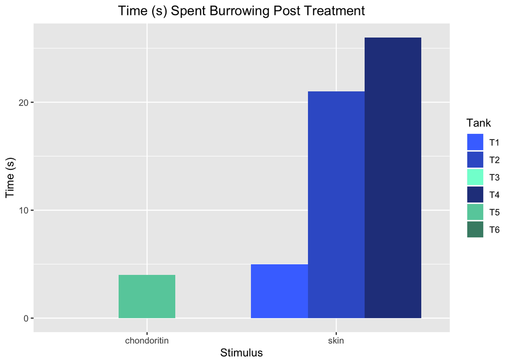

## 4.6 Freezing

A t-test was used to compared the time fish spent freezing once the stimulus was added. There was not a significant difference (p=0.27) in time spent freezing between the fish exposed to chondoritin and those exposed to skin extract. This result may be due to the fact that the majority of tanks had slow moving fish to begin with. There was only one tank that didn’t display any freezing, and that tank was one that was exposed to chondoritin. These fish were very active throughout their entire six minute trial, with one exceedingly aggressive fish in the tank.

```
##
##  Welch Two Sample t-test
##
## data:  Freezing by Stimulus
## t = -1.1338, df = 12.746, p-value = 0.2778
## alternative hypothesis: true difference in means is not equal to 0
## 95 percent confidence interval:
##  -68.85454  21.52121
## sample estimates:
## mean in group chondoritin        mean in group skin
##                  56.88889                  80.55556
```

| Stimulus | Freezing | Tank | Fish |
| --- | --- | --- | --- |
| skin | 45 | T1 | 1 |
| skin | 101 | T1 | 2 |
| skin | 153 | T1 | 3 |
| skin | 85 | T2 | 1 |
| skin | 64 | T2 | 2 |
| skin | 71 | T2 | 3 |
| skin | 71 | T4 | 1 |
| skin | 70 | T4 | 2 |
| skin | 65 | T4 | 3 |
| chondoritin | 0 | T3 | 1 |

[output cut: 8 more lines]

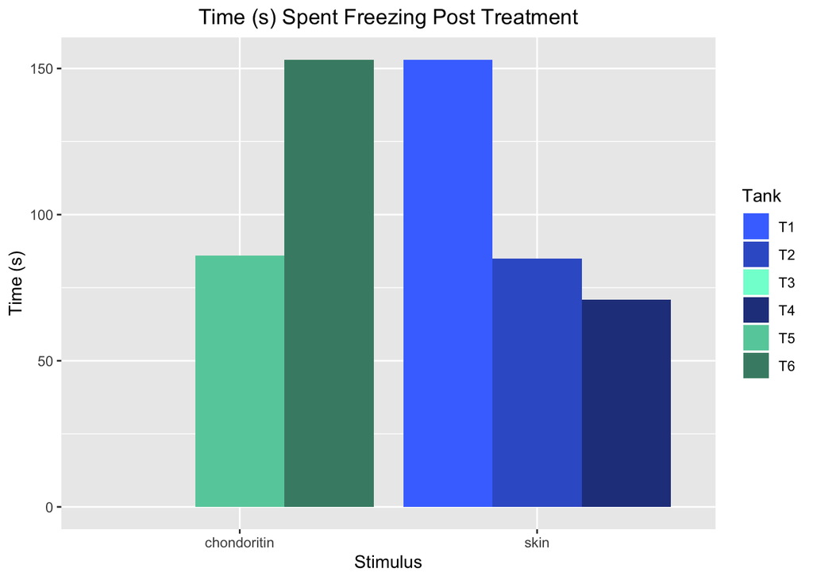

# 5 References

Fansley, S., Kuhajda, B., George, A., and Klug, H. 2016. Fundulus catenatus (Northern Studfish) response to the potential alarm cue chondroitin sulfate. Southeastern Naturalist. 15:523-533.

Magurran, A. E., P. W. Irving, and P. A. Henderson. 1996. Is there a fish alarm pheromone? A wild study and critique. Proceedings of the Royal Society B: Biological Sciences 263:1551–1556.

Mathuru, A. S., C. Kibat, W. F. Cheong, G. Shui, M. R. Wenk, R. W. Friedrich, and S. Jesuthasan. 2012. Chondroitin fragments are odorants that trigger fear behavior in fish. Current Biology 22:538–544.

Pfeiffer, W. 1977. The Distribution of Fright Reaction and Alarm Substance Cells in Fishes. Copeia 1977:653–665.

Smith, R. J. F. 1992. Alarm signals in fishes. Reviews in Fish Biology and Fisheries 2:33–63.